# Chapter 2: Counting Words in the 19th-Century British Parliamentary Debates

## Critical Thinking With Collocates

When is collocate analysis the right method? Researchers of conceptual history frequently use collocates to understand the subtle differences between synonyms. For instance, historian Ruben Ros has investigated the way that Dutch newspapers in the nineteenth century began to use terms such as “foreign,” “overseas,” and “strange” in the process of constructing a narrative that increasingly linked the dangers of foreign influence and suspicion of ethnic minorities.<sup>11</sup>

With collocate analysis alone, we cannot trace discourses over time – a crucial step in understanding the construction of political and cultural positions. But we can begin to tease apart the meanings of closely-related ideas at various points in the past. We can recreate Ro’s approach in miniature here, asking the question: how did British members of parliament in the 1850s talk about foreigners and colonial subjects?

## Creating Functions

Our research questions might necessitate analytical steps that go beyond the built-in functions provided to us in R packages alone. We may want to create our own functions to customize how words are identified, filtered, or visualized so that the analysis reflects our specific research goals. Or, we might want to create reusable code that keeps us from rewriting the same data processing steps over and over. To demonstrate our point, we are going to write a basic, reusable function for counting and visualizing words. First, however, we want to provide a basic understanding of a function’s underlying components, by creating a simple function:

```r
# Define a function that adds two numbers
# - function() creates a reusable block of code
# - a and b are the inputs to the function
# - return() returns the sum
add_numbers <- function(a, b) {
  result <- a + b # Add the two numbers
  return(result) } # Return the result
```

The above code can be broken down into these core parts:

1. Function Name: The name given to the function. In this example, the function is named `add_numbers`.
2. Parameters: The variables listed in the function definition that will accept arguments, for instance, `function(a, b)`.
3. Body: The code that is executed when the function is called, written here as `result <- a + b`.
4. Return Value: The output produced by the function, for example, `return(result)`.

Every function in R encapsulates a code body, even when it is hidden from the analyst.

We can now use our new `add_numbers()` function by passing arguments to the specified parameters. In this example, the “a” parameter is passed the number 2, and the “b” parameter is passed the number 3. The two numbers are added in the body, and then the results are returned.

Now that we have defined this function, we can call upon it whenever we need to add two numbers without rewriting the steps involved. This kind of reuse becomes especially important in historical analysis, which is often iterative and rarely linear. As our interpretations shift and our questions evolve, we often return to the same operations with new purposes. Having stable tools like functions allows us to revisit and revise our analyses without starting from scratch each time.

```r
# Use the add_numbers() function
# - provide 2 and 3 as the inputs
# - print() displays the returned result
print(add_numbers(2, 3))
```

```
## [1] 5
```

In the following code we create a function for filtering the Hansard data for a keyword, and visualizing the top 20 words. These are the same series of steps we have performed already, but here we are using our function to produce a series of related graphs in succession without writing out the same instructions multiple times.

```r
# Define a function to visualize the most common words that co-occur with a keyword
# - keyword specifies the word to search for
# - hansard_data is the dataset to search
generate_word_plot <- function(keyword, hansard_data) {

    # Filter speeches containing the keyword and count the most common words
    filtered_hansard_1850 <- hansard_data %>%
      filter(str_detect(text, regex(paste0("\\b", keyword, "\\b"),
                                    ignore_case = TRUE))) %>% # Keep speeches containing the keyword
      unnest_tokens(word, text) %>% # Tokenize the text into words
      anti_join(stop_words) %>% # Remove common stop words
      filter(!str_detect(word, "[:digit:]")) %>% # Remove words containing digits
      count(word) %>% # Count the occurrences of each word
      top_n(20) # Keep the 20 most frequent words

    # Create the bar chart
    plot <- ggplot(filtered_hansard_1850) + # Start the plot
      geom_col(aes(x = reorder(word, n), # Order words by frequency
                   y = n), # Plot word counts
               fill = "steel blue") + # Color the bars
      coord_flip() + # Flip the axes
      labs(title = paste("Top Words Occurring in Sentences Mentioning",
                         toupper(keyword)), # Add a chart title
           subtitle = "From the 1850 Hansard debates", # Add a subtitle
           x = "Word", # Label the x-axis
           y = "Count") # Label the y-axis

    print(plot) } # Display the plot
```

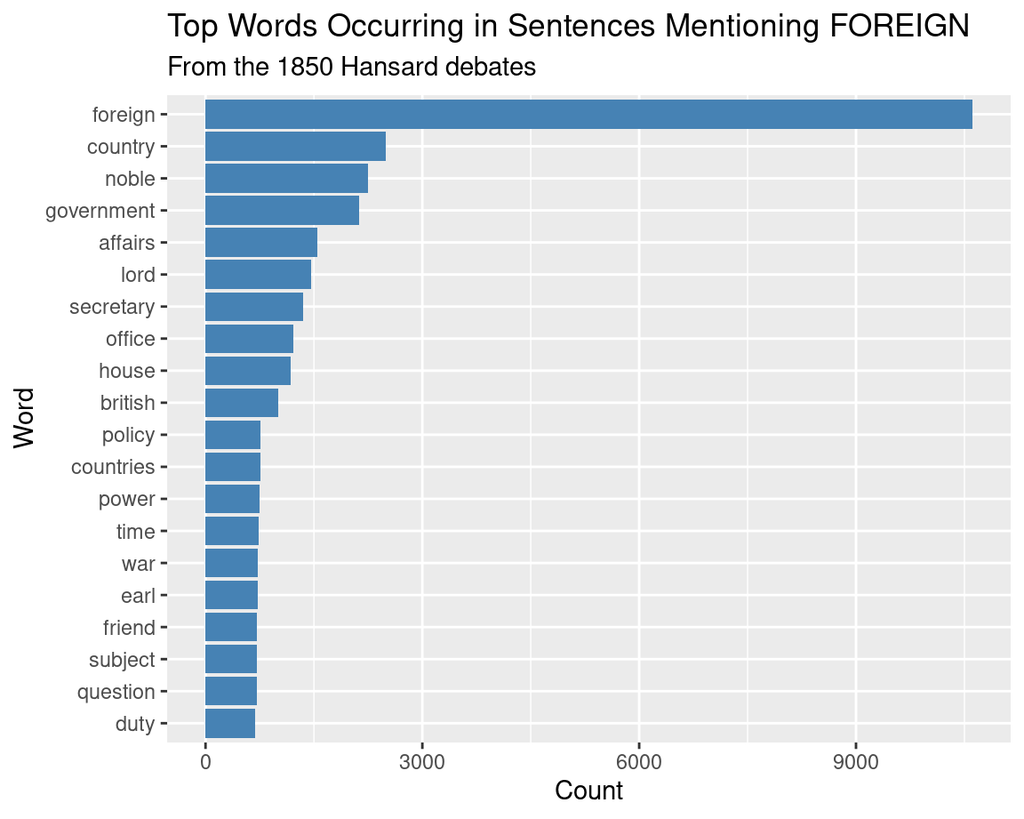

Top words in sentences mentioning foreign (Hansard, 1850)

```r
# Use the generate_word_plot() function
# - search for the word "foreign"
# - create a bar chart of the most common words in matching speeches
generate_word_plot("foreign", hansard_1850) # Plot the top words that co-occur with "foreign"
```

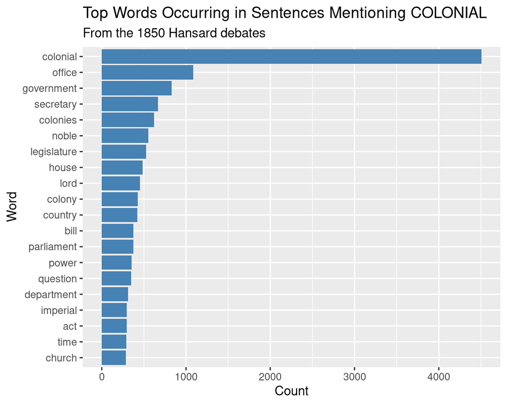

Top words in sentences mentioning colonial (Hansard, 1850)

```r
# Do the same for sentences that mention the word "colonial"
generate_word_plot("colonial", hansard_1850)
```

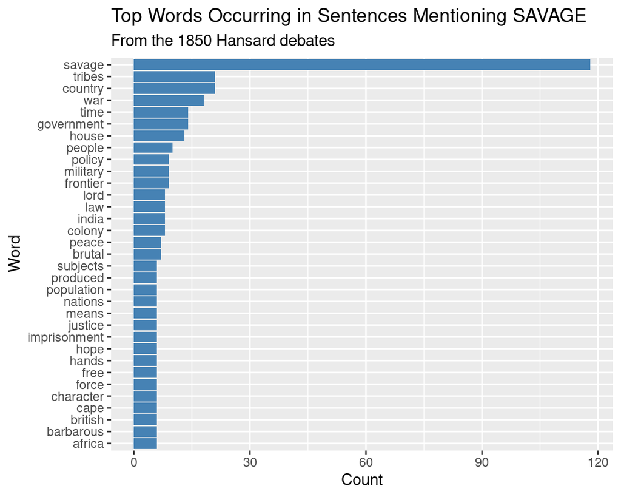

Top words in sentences mentioning savage (Hansard, 1850)

```r
# Do the same for sentences that mention the word "savage"
generate_word_plot("savage", hansard_1850)
```

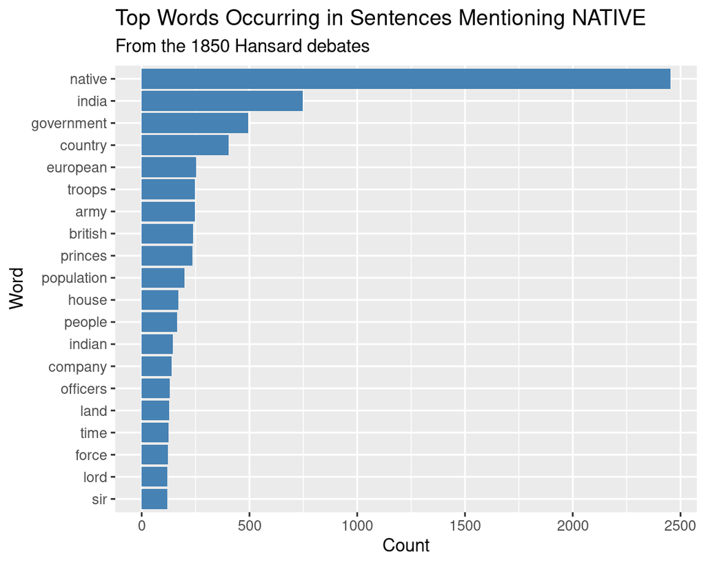

Top words in sentences mentioning native (Hansard, 1850)

```r
# Do the same for sentences that mention the word "native"
generate_word_plot("native", hansard_1850)
```

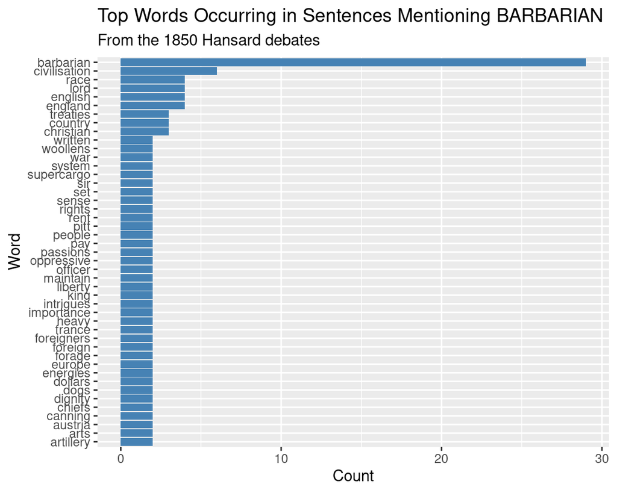

Top words in sentences mentioning barbarian (Hansard, 1850)

```r
# Do the same for sentences that mention the word "barbarian"
generate_word_plot("barbarian", hansard_1850)
```

Producing many graphs in succession (as demonstrated by Figures 1.3 to 1.7) can be useful for exploratory data analysis. Performing a comparative analysis of graphs side-by-side is one of the main skills digital humanists use when considering the subtle structures of meaning and difference that define cultural and political conversations. A careful comparison between the charts above offers the beginnings of a nuanced analysis of overlapping terms used by British members of parliament to refer to people and forces from beyond Britain.

Examining collocates provides the basis for critical thinking about the changing and overlapping meaning of shared concepts in the human past. Skillful analysts can use approaches of this kind to examine the meaning of language about categories beyond those of gender, race, nationality, and commodities, asking questions about the intellectual categories that governed how members of parliament understood governance itself, economics, truth, science, virtue, economics, and reason itself. In every case, the approach would be the same: to examine not merely one or two keywords, but many related keywords, drawing attention to the subtle overlap and differences between the terms in usage, and how those overlapping concepts together work to produce a field of meaning.

## Critical Thinking About Data and its Limits

Another fruitful avenue for critical thinking is the question of which problems are suited to textual analysis and which are not. Skillful analysts are wary of asking the wrong question with the wrong tool. Among the techniques that we have learned in this chapter is the ability to load and inspect data. Inspecting the data allows the analyst to notice issues caused by computational processing of text that may cause issues down the line unless the analyst is aware of them.

Looking at the first lines of `hansard_1850`, you might ask yourself these questions: are all of the lines in the “text” field actually sentences? Are all the words in the same style with respect to capitalization? We can inspect this further.

Analyzing the entire data frame to further inspect the data can be distracting since a data frame usually contains multiple columns, some which may be irrelevant to our current query.

```r
# Display the first six rows of the Hansard dataset with metadata
# - head() keeps the first six rows
# - kable() formats the results as a table
hansard_1850_with_metadata %>%
  head() %>% # Keep the first six rows
  kable() # Format the results as a table
```

| sentence_id | text | speechdate | debate |
| --- | --- | --- | --- |
| S3V0108P0_0 | , which had been prorogued successively from the 1st of August to the 9th of October, from thence to the 20th of November, thence to the 16th of January, and from thence to the 31st January, met this … | 1850-01-31 | MEETING OF PARLIAMENT. |
| S3V0108P0_1 | The Parliament was opened by Commission, the LORDS COMMISSIONERS present being the LORD CHANCELLOR; the LORD PRESIDENT OF THE COUNCIL (the Marquess of Lansdowne); the LORD PRIVY SEAL (the Earl of Mint… | 1850-01-31 | MEETING OF PARLIAMENT. |
| S3V0108P0_2 | called attention to a great omission of their duty on the part of Ministers, with respect to the privileges of their Lordships, which might and ought to have been avoided. | 1850-01-31 | SCOTCH REPRESENTATIVE PEERS. |
| S3V0108P0_3 | At pre-sent there were two vacancies in the representative Peers of Scotland, in consequence of the deaths of the Earl of Airlie and of Lord Colville. | 1850-01-31 | SCOTCH REPRESENTATIVE PEERS. |
| S3V0108P0_4 | Although the Act of Parliament directed that the proclamation should issue forthwith for the election of representative Peers to fill up any vacancies which might occur, by death or otherwise, no such… | 1850-01-31 | SCOTCH REPRESENTATIVE PEERS. |
| S3V0108P0_5 | The Peerage of Scotland was not therefore represented in Parliament at present as it ought to be. | 1850-01-31 | SCOTCH REPRESENTATIVE PEERS. |

We can make the data more readable by displaying just the data from the column of interest.

In the following code, we use `hansard_1850[[2]][1:10]` to select the first ten text entries from the second column of hansard_1850. The double brackets, `[[2]]`, select the second column, which contains the text of the Hansard debates. We then use `[1:10]` to select the first ten entries from that column.

```r
# View rows 1 to 10 from the 2nd column of the hansard_1850 dataset
hansard_1850[[2]][1:10]
```

```
##  [1] ", which had been prorogued successively from the 1st of August to the 9th of October, from thence to the 20th of November, thence to the 16th of January, and from thence to the 31st January, met this day for despatch of business."
##  [2] "The Parliament was opened by Commission, the LORDS COMMISSIONERS present being the LORD CHANCELLOR; the LORD PRESIDENT OF THE COUNCIL (the Marquess of Lansdowne); the LORD PRIVY SEAL (the Earl of Minto); the LORD CHAMBERLAIN OF THE HOUSEHOLD (the Marquess of Breadalbane); and the LORD BISHO…
##  [3] "called attention to a great omission of their duty on the part of Ministers, with respect to the privileges of their Lordships, which might and ought to have been avoided."
##  [4] "At pre-sent there were two vacancies in the representative Peers of Scotland, in consequence of the deaths of the Earl of Airlie and of Lord Colville."
##  [5] "Although the Act of Parliament directed that the proclamation should issue forthwith for the election of representative Peers to fill up any vacancies which might occur, by death or otherwise, no such proclamation had yet taken place in the case of the two vacancies he had just mentioned, a…
##  [6] "The Peerage of Scotland was not therefore represented in Parliament at present as it ought to be."
##  [7] "He wanted to know what his noble Friend the President of the Council had to urge in defence of this omission; for certain it was that the Act of Parliament had not been obeyed?"
##  [8] "said, that the Government were not to blame for the omission, as they had not received any requisition from the usual quarter; they had strictly followed the previous usage."
##  [9] "said, the explanation of the noble Marquess was unsatisfactory."
## [10] "The clause in 5 & 6 Anne, c. 8, directed what should be done in the case of vacancies by death, and the words could not well be misunderstood."
```

Some of the rows in the “text” field appear not to be complete sentences. We can investigate this oddity further.

In the following code, we use `hansard_1850[[2]][1]` to select specific text from `hansard_1850`. This time we will view just the first row.

```r
# View the first row from the 2nd column of the hansard_1850 dataset
hansard_1850[[2]][1]
```

```
## [1] ", which had been prorogued successively from the 1st of August to the 9th of October, from thence to the 20th of November, thence to the 16th of January, and from thence to the 31st January, met this day for despatch of business."
```

Viewing the dataset this way also displays additional formatting that can make longer passages difficult to read. To view the complete text more clearly, double-click the cell, then copy and paste the text into a word processor. The passage reads as follows:

> “, which had been prorogued successively from the 1st of August to the 9th of October, from thence to the 20th of November, thence to the 16th of January, and from thence to the 31st January, met this day for despatch [sic] of business.”

The first row appears to be a description of the opening of parliament. Technically, it is a commentary by the printer, not a line of debate. The convention of discussing parliament’s timetables was in place in 1850, but we do not know if the printer always printed this line through the entire century. We should be aware of this convention and curious about it if we find ourselves counting months or discussions of words such as “business.”

Let’s keep inspecting the data, this time turning to the third row in our dataset.

```r
# View the third row from the 2nd column of the hansard_1850 dataset
hansard_1850[[2]][3]
```

```
## [1] "called attention to a great omission of their duty on the part of Ministers, with respect to the privileges of their Lordships, which might and ought to have been avoided."
```

Here, we see another sentence fragment:

> “called attention to a great omission of their duty on the part of Ministers, with respect to the privileges of their Lordships, which might and ought to have been avoided.”

The sentence fragment has resulted from attempting to process data while working on another convention of printing: the fact that the publisher of Hansard for much of the century gave the name of the speaker followed by a description of the airing of the speech. On the page, we would be given the name of a speaker or their title, for example, “The Lord Chancellor” or “Mr. Gladstone.” The passage of text would therefore read, [the speaker] “called attention to a great omission…” – in other words, it would not be a sentence fragment, so much as a journalistic description of a speaker. The actual speech probably began with a statement something like this: “It is a great omission of their duty on the part of Ministers[…].” In other words, we are looking at an oddity that resulted from a mismatch between the 19th-century printed record and how the computer processed the data. We compiled the data and separate all of the speaker names into one “field” of data, which we stored in a separate dataset, to be accessed in Chapter 2. We have sorted all of the text into the “text” field, which is held in `hansard_1850`. The computer did not process the journalistic description of a speech rather than a normal speech.

Looking at the data presents an opportunity for critical thinking. Analysts of text as data routinely need to inspect their data and make sure that the data’s quality and density are sufficient to support claims that they might make.

Already, we can see that the data has certain features that might interfere with certain kinds of queries, and we should already be thinking about what these limits might be. Yet the convention of journalistic reporting on speeches can cause trouble for the analyst if the analysts are not aware of what has changed. The conventions of describing speeches changed over the course of the century; at the beginning of the century, journalistic descriptions were more common. Later in the century, the conventions changed, and many more speeches were reported near verbatim without journalistic commentary. We should be aware of conventions of this kind if we count words which may be related to journalistic observations such as “attention,” “spoke,” “declared,” and so on. Otherwise we may be tempted to interpret changes to the publisher’s conventions of printing speeches as evidence for changing ideas about politics.

Whether or not data quality will interfere with our ability to make inferences from the data depends on what we are asking. If we are counting mentions of the word “duty” or the rest of the words in the content of the speech, then our counts of the words will be correct. If we contrive to study the history of journalistic observation by tracking sentence fragments in the dataset, this data will support such a reading. But we should be wary making inferences about any kind of inquiry where there is a risk of overlap between substantive discussions and journalistic observation.

## Exercises

Expand your grasp of the code and your powers of critical reflection by trying the following exercises:

1. Alter the code above to compare the context for the keywords “girl” and “woman.” Do you expect the context to be similar for both? Does anything surprise you about the results?
2. Some of the terms for women and men on your list may be slangy and pejorative, even offensive. Given our intention of understanding how parliament — a body of privileged white men — talked about the individuals ruled by parliament, do we need to understand the frequency of those terms? Or conversely should they be filtered out because they are insensitive? What is the best approach for your readers?
3. Use your powers of inspecting data to move from the keyword context back to the individual sentences. Cut and paste twenty sentences from the context of each keyword into a word processor. What do you learn from these sentences that you did not learn from counting keywords? Does your analysis become more persuasive when quantitative graphs are accompanied with readings of particular speeches where the words are examined in their original context?
4. We have examined ‘coal’ and ‘corn’ in the 1850s. Now, search for the words ‘coal’ and ‘corn’ in dataset `hansard_1820`. Were they being used in the same way? What changed?
5. In “Tailoring our Word Count Analysis”, we created the list of words called `identifiers_for_woman`. Create another list called `identifiers_for_man` and do the same for discussions of men. Create visualizations for the top terms used in discussions of men and women.
6. Query an AI—such as ChatGPT—for alternative words referring to men and women. Then evaluate the results critically. Do the suggested terms seem appropriate for the historical context you are studying? Do they improve your search results, or do they introduce irrelevant or misleading matches? When you use these additional terms in your corpus search, do you retrieve more relevant examples, or simply more noise? Finally, consider whether some suggested words may be anachronistic or culturally inappropriate for the nineteenth century, which could affect the validity of your analysis.
7. Reflect on your work so far – in which you have compared words for gender, the concept of the foreign, and the context of discussions of different commodities. You have made comparisons over time and comparisons of lists. Which of the comparisons do you find the most productive of insight about how certain words were being used in political debate? Are you persuaded by large numbers? Are you persuaded by subtle variations in the context of different words? Write a paragraph explaining for yourself wherein constitutes the most persuasive usage of comparisons between keyword in context.
8. For the visualizations of the terms associated with different terms for the “foreign,” tell us: What biases does each term convey? Where do the terms overlap? What new information is encapsulated by some words but not others? What do we learn from this exercise about the prejudices of Britain’s members of parliament in the 1850s?